# Homework5-DataVis-ggplot

Arielle Pastore

DUE: Thursday, March 10

#### Necessary items:

- **libraries:** tidyverse, ggsci, ggforce, patchwork, Hmisc
- **files:** bloom_df.csv, hw_task2_blank.png

Within RStudio you can directly edit these blocks of code and turn in your homework that way with your code and figures printed.  
I **HIGHLY** recommend getting your code to work in a normal R script then just copy and pasting the final code over to this document

**First: import libraries, set your working directory, and read in bloom_df**

```r
library(tidyverse)
library(ggforce)
library(ggsci)
library(patchwork)
library(Hmisc)

setwd('/Users/ariellejewelpastore/Desktop/hw5/Part.4.DataVisualization/ggplot') #change to match your ggplot directory

bloom_df <- read.csv('bloom_df.csv')
```

### bloom_df contents

- **taxa:** genus_species
- **genus**
- **species**
- **logbodysize**
- **trophic_position**
- **reg:** diadromous or non-diadromous

Let’s take a peak and look at the structure

```r
bloom_df[1:5,]
```

```
##                   taxa genus        species logbodysize trophic_position
## 1       Alosa_alabamae Alosa       alabamae    1.707570        0.4313638
## 2          Alosa_alosa Alosa          alosa    1.778151        0.5563025
## 3         Alosa_fallax Alosa         fallax    1.778151        0.5563025
## 4      Alosa_mediocris Alosa      mediocris    1.778151        0.6127839
## 5 Alosa_pseudoharengus Alosa pseudoharengus    1.602060        0.5440680
##          reg
## 1 diadromous
## 2 diadromous
## 3 diadromous
## 4 diadromous
## 5 diadromous
```

```r
str(bloom_df)
```

```
## 'data.frame':    50 obs. of  6 variables:
##  $ taxa            : chr  "Alosa_alabamae" "Alosa_alosa" "Alosa_fallax" "Alosa_mediocris" ...
##  $ genus           : chr  "Alosa" "Alosa" "Alosa" "Alosa" ...
##  $ species         : chr  "alabamae" "alosa" "fallax" "mediocris" ...
##  $ logbodysize     : num  1.71 1.78 1.78 1.78 1.6 ...
##  $ trophic_position: num  0.431 0.556 0.556 0.613 0.544 ...
##  $ reg             : chr  "diadromous" "diadromous" "diadromous" "diadromous" ...
```

### Graphical tasks

This next tasks are going to ask you to make a series of figures. For each one, I would like you to make all of them *look good*. Change the theme around, change the axis labels, etc. Additionally, each of these will use the **reg** column which has 2 factors. Change the color and/or shape of them both.

### Task 1: Continuous vs. continuous plot

Create two scatterplots of logbodysize vs. trophic_position grouped by reg

##### First plot:

- a 2 trend lines (method = ‘lm’), one for each reg variable

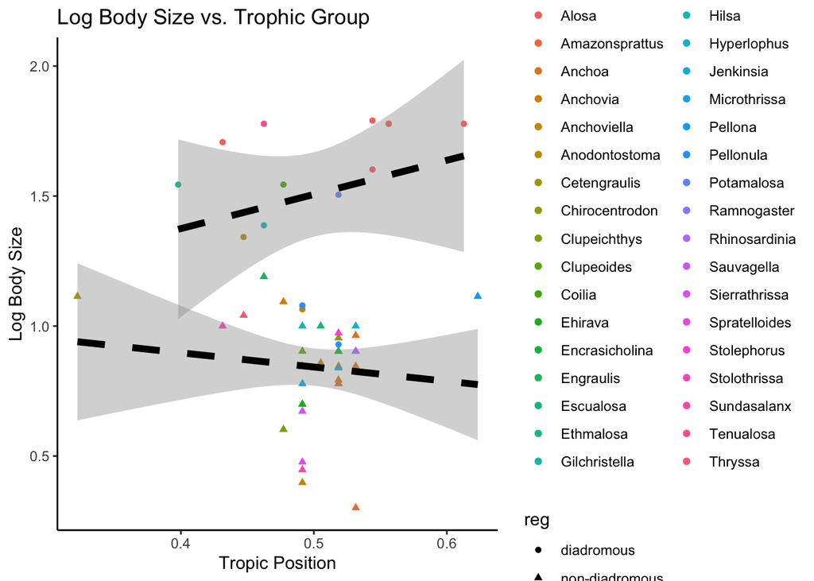

```r
#plot 1.1
ggplot(data=bloom_df, aes(x=trophic_position, y=logbodysize, color = genus, pch = reg), group_by(reg)) + geom_point(method = lm) + ggtitle('Log Body Size vs. Trophic Group') + xlab('Tropic Position') + ylab('Log Body Size') + theme_bw() + stat_smooth(method='lm',linetype='dashed',colour='black',linewidth=2) + theme_classic()
```

##### Second plot

- a single trend line for the whole model

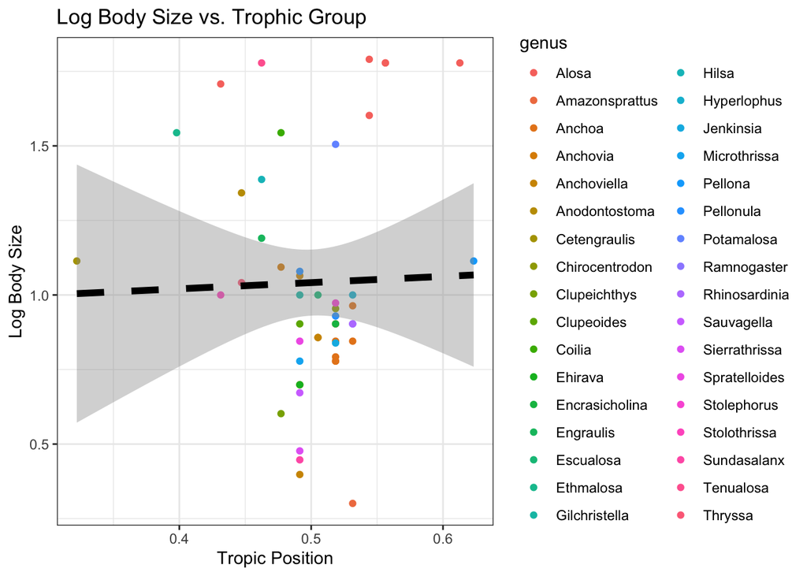

```r
#plot 1.2
ggplot(data=bloom_df, aes(x=trophic_position, y=logbodysize, color = genus)) + geom_point(method = lm) + ggtitle('Log Body Size vs. Trophic Group') + xlab('Tropic Position') + ylab('Log Body Size') + theme_bw() +  stat_smooth(method = 'lm', linetype='dashed',colour='black',linewidth=2)
```

### Task 2: Continuous vs. categorical

##### The layout will be:

- 2 panels: trophic_position and logbodysize
- x axis: reg
- y axis: value of trophic_position and logbodysize

##### Create 4 plots:

- bar and error bars (mean and 95% conf. int.)
- point and error bars (mean and 95% conf. int.)
- box plots
- raw data + point and error bars (mean and 95% conf. int.)

All these plots should have the same general layout but change the type of plot to visualize the data.

**HINT:** logbodysize and trophic_position need to be turned into long format

##### Example layout:

[figure not shown]

sample layout for task2

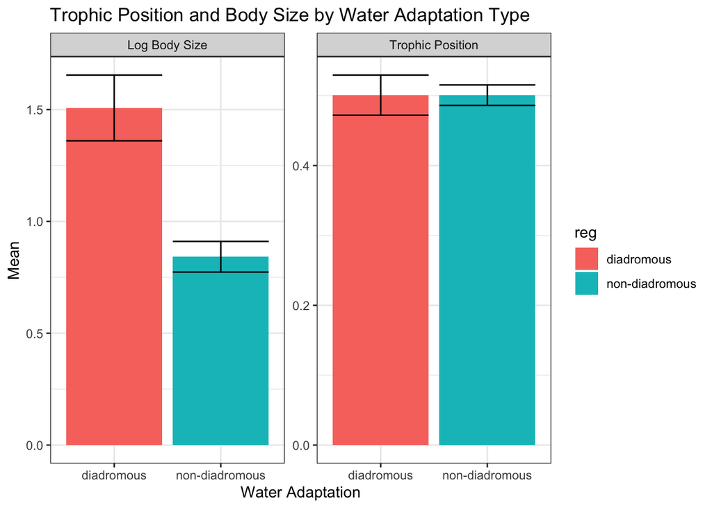

```r
body_sum_df <- bloom_df %>%
  group_by(reg) %>%
  summarise(mean = mean(logbodysize, na.rm = TRUE), #temp mean
            sd = sd(logbodysize, na.rm = TRUE), #temp standard deviation
            n = n()) %>% #temp count
  mutate(se = sd / sqrt(n), #Temp standard error
         ci = 1.96 * se) #Temp 95% confidence interval

view(body_sum_df)
body_sum_df$Measure <- 'Log Body Size'
view(body_sum_df)


troph_sum_df <- bloom_df %>%
  group_by(reg) %>%
  summarise(mean = mean(trophic_position, na.rm = TRUE), #Ppt mean
            sd = sd(trophic_position, na.rm = TRUE), #Ppt standard deviation
            n = n()) %>% #Ppt count
  mutate(se = sd / sqrt(n), #Ppt standard error
         ci = 1.96*se) #Ppt 95% confidence interval
view(troph_sum_df)
troph_sum_df$Measure <- 'Trophic Position'
view(troph_sum_df)

bloom_sum_df2 <- rbind(body_sum_df,troph_sum_df)
view(bloom_sum_df2)

#plot 2.1

ggplot(data=bloom_sum_df2,aes(x=reg,y=mean,fill=reg)) +
  facet_wrap(~Measure,nrow=1,scales = 'free') + geom_bar(stat='identity') + theme_bw() +xlab('Water Adaptation') + geom_errorbar(aes(ymin = mean - ci, ymax = mean + ci)) + ylab('Mean') + ggtitle('Trophic Position and Body Size by Water Adaptation Type')
```

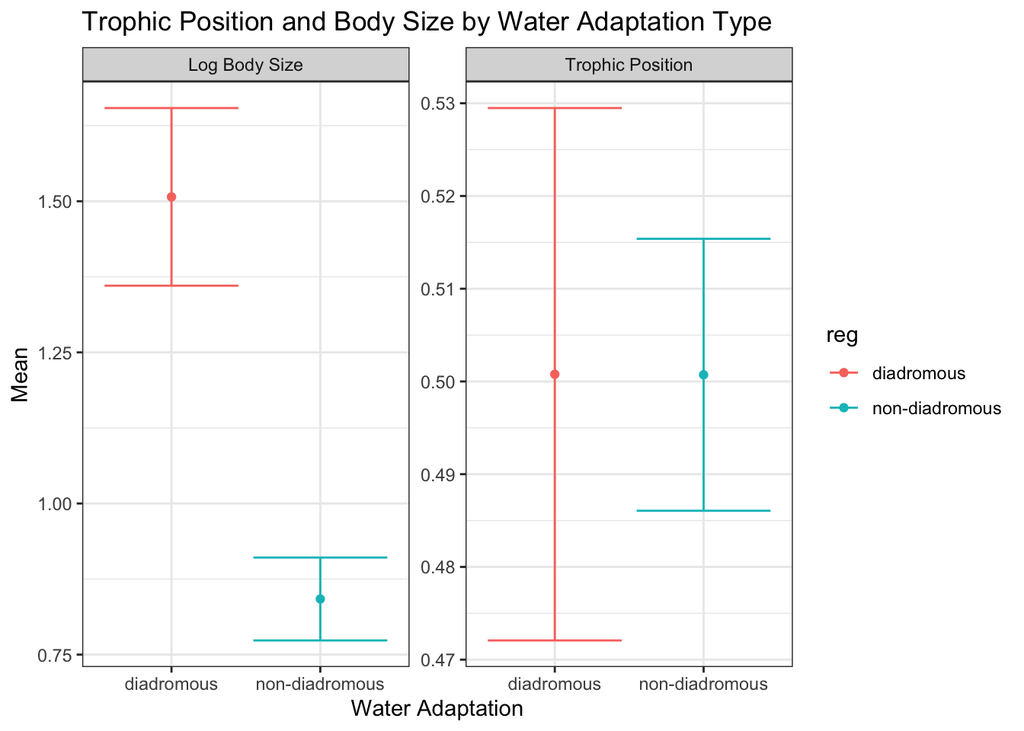

```r
#plot 2.2
ggplot(data=bloom_sum_df2,aes(x=reg,y=mean,color=reg)) +
  facet_wrap(~Measure,nrow=1,scales = 'free') + geom_point(stat='identity') + theme_bw() +xlab('Water Adaptation') + geom_errorbar(aes(ymin = mean - ci, ymax = mean + ci)) + ylab('Mean') + ggtitle('Trophic Position and Body Size by Water Adaptation Type')
```

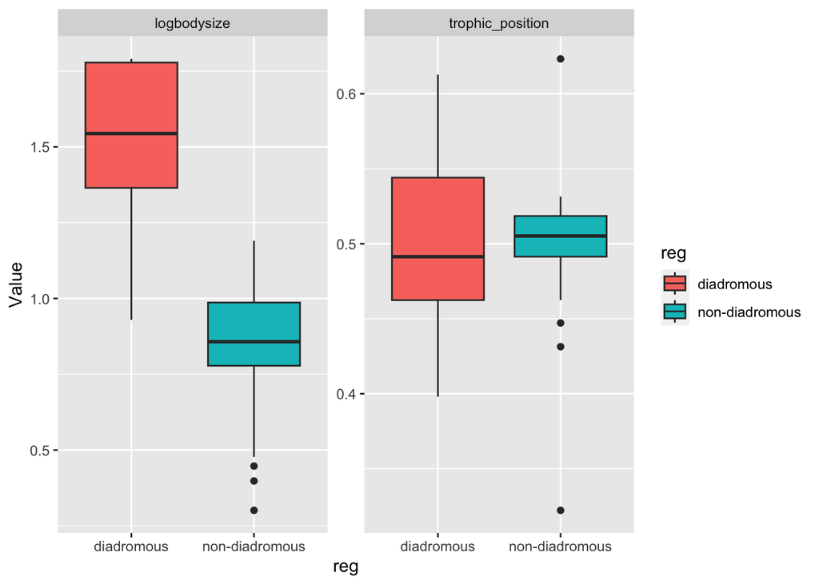

```r
bloom_long_df <- bloom_df %>%
  pivot_longer(cols = c(logbodysize, trophic_position), names_to = "Measure", values_to = "Value")
view(bloom_long_df)
#plot 2.3
ggplot(data=bloom_long_df,aes(x=reg,y=Value,fill=reg)) +
  facet_wrap(~Measure,nrow=1,scales = 'free') +
  geom_boxplot()
```

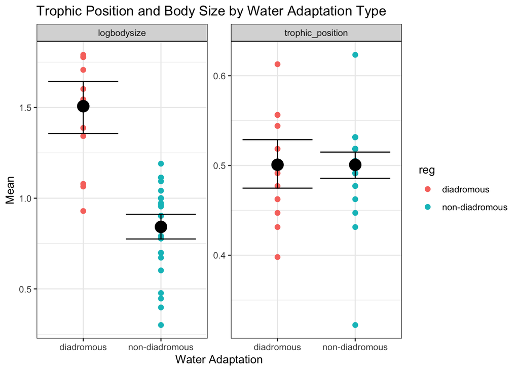

```r
#plot 2.4
ggplot(data=bloom_long_df,aes(x=reg,y=Value,color=reg)) +
  facet_wrap(~Measure,nrow=1,scales = 'free') +
  geom_point(size=2) +
  stat_summary(fun.data = mean_cl_boot, geom = "errorbar",color="black") +
  stat_summary(fun = mean, geom = "point",size=5,colour="black") + theme_bw() +xlab("Water Adaptation") + ylab('Mean') + ggtitle('Trophic Position and Body Size by Water Adaptation Type')
```

### Task 3: layering your plots

Make any two figures with the bloom_df! Can be something we’ve done or something completely different. Make one TERRIBLE figure and one GREAT figure.

Put them together using *patchwork* or *ggarrange*

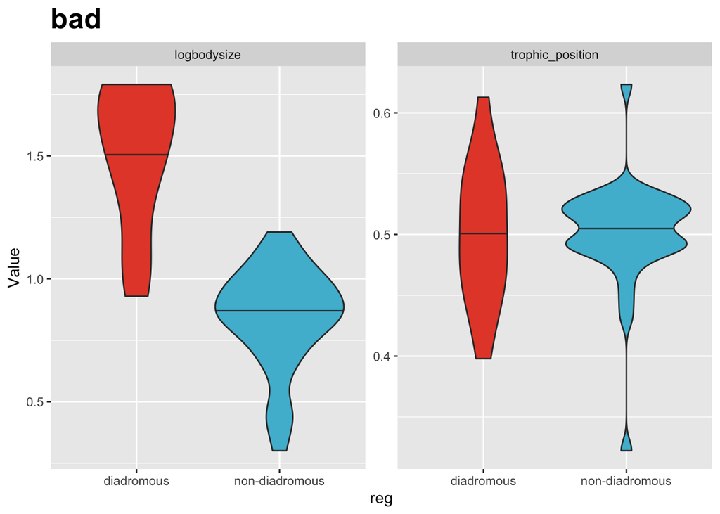

```r
#plot 3
bad_plot <- ggplot(data=bloom_long_df,aes(x=reg,y=Value,fill=reg)) +
  facet_wrap(~Measure,nrow=1,scales = 'free') + geom_violin(draw_quantiles = 0.5) +
  scale_fill_npg() +
  ggtitle('bad') +
  theme(legend.position='none',
        plot.title = element_text(size = 20, colour="black",face = "bold"))
bad_plot
```

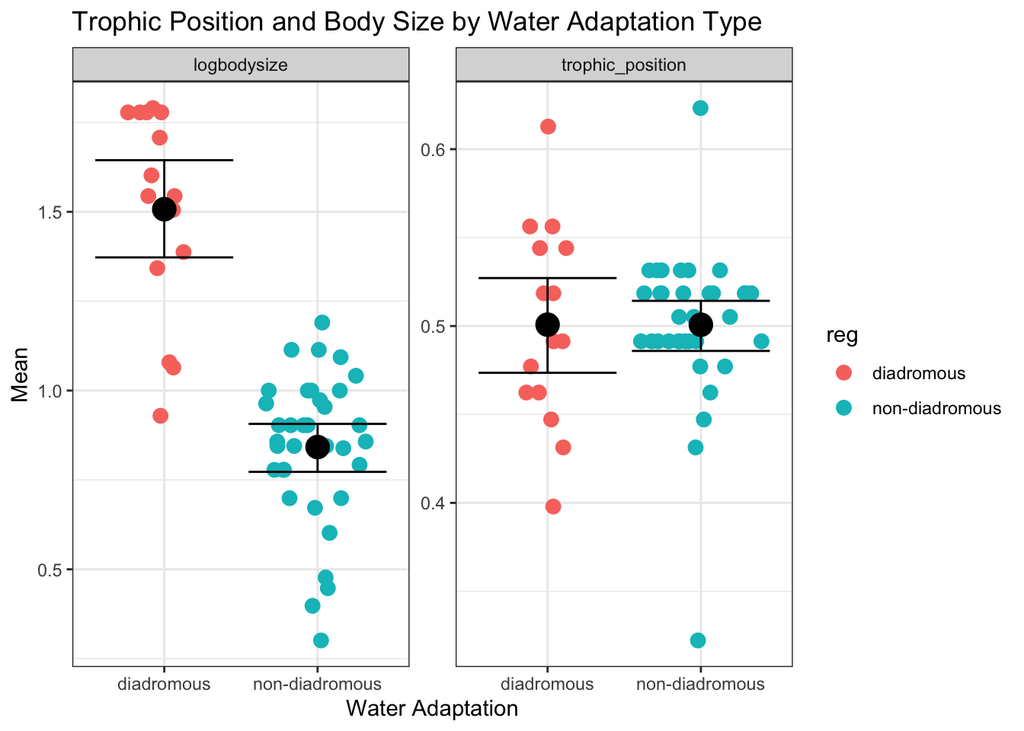

```r
good_plot <- ggplot(data=bloom_long_df,aes(x=reg,y=Value,colour=reg)) +
  facet_wrap(~Measure,nrow=1,scales = 'free') +
  geom_sina(size=3) +
  stat_summary(fun.data = mean_cl_boot, geom = "errorbar",color='black') +
  stat_summary(fun = mean, geom = "point",size=5,colour='black') + theme_bw() +xlab("Water Adaptation") + ylab('Mean') + ggtitle('Trophic Position and Body Size by Water Adaptation Type')

good_plot
```

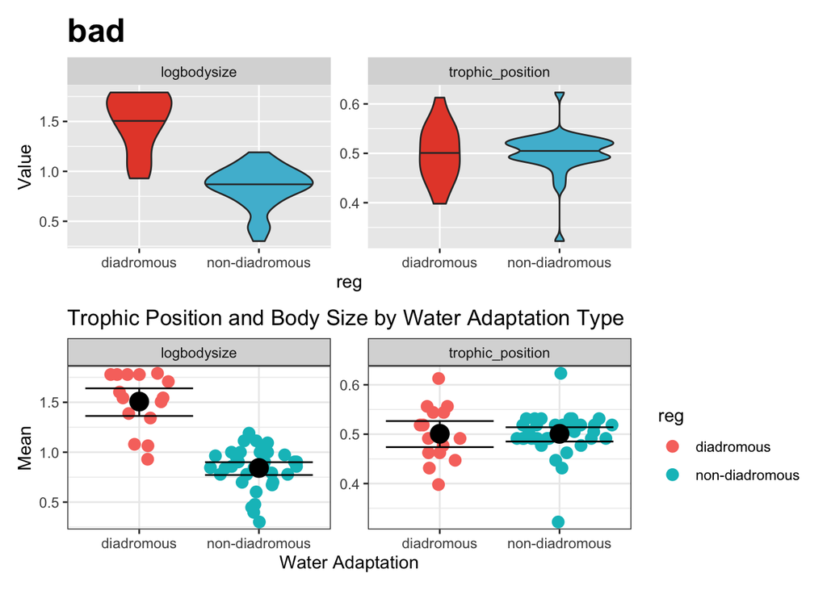

```r
bad_plot / good_plot
```

### Bonus: make a map (not required)

In the github for this course, there is an Rmarkdown called *ggmap_ex*. You can use this as a reference to make a map using any data you want. Try using your own data so it is useful.

```r
#bonus map
```